# Working from home and digital divides: resilience during the pandemic

Hannah Budnitz & Emmanouil Tranos University of Bristol, Alan Turing Institute e.tranos@bristol.ac.uk [@EmmanouilTranos](https://twitter.com/EmmanouilTranos) [etranos.info](https://etranos.info/)

## Cite:

Budnitz, H., and E. Tranos (2021) Working from home and digital divides: resilience during the pandemic. *Annals of the AAG*. In press. [link](https://doi.org/10.1080/24694452.2021.1939647)  
etranos.info/post/rinr2021

## Contents

- Introduction
- Experienced broadband speed data
- Analysis
- Conclusions

# Introduction

## WFH / Telecommuting

- From a niche means of accessing work to a widespread way of life
- From $5$% to $47$% in the UK (ONS 2020a, 2020b)
- $37$% WFM in European April $2020$
- $60$% in Finland (Eurofound 2020)
- Almost $50$% in the US, $37$% could be permanently moved online (Brynjolfsson et al. 2020; Dingel and Neiman 2020)

## WFH / Telecommuting

- WFH = economic resilience during Covid-19
- Capability to WFH:
  - occupations
  - quality digital infrastructure
- Spatial clustering and dependence

## Digital divides

- 1st level: availability and quality of internet connectivity
- 2nd level: skills to effectively utilise digital technologies
- 3rd level: returns of internet usage
- Cross-level interactions

## Our approach

- Intersection of digital and material divides
- Economic resilience of places as digital technologies became an essential tool of productivity during the pandemic  
  **internet services + occupations $\Rightarrow$ WFM $\Rightarrow$ economic resilience**

## Our approach

- UK Local Authorities Districts (LAD) as a case study
- Quality of internet service: *experienced* internet speeds during the spring $2020$ lockdown
- Time-series clustering to create clusters of local authorities with similar temporal signatures of internet speeds
  - $\Rightarrow$ 1st level of digital divide
- Regress cluster membership against their socioeconomic and geographic characteristics
  - $\Rightarrow$ how the 1st level of digital divide intersects with the 2nd and 3rd

# Data

## Experienced Broadband Speeds

- *Experienced* vs. advertised internet speeds
- $\Uparrow$ internet demand usage $\Downarrow$ experienced internet speed
- www.broadbandspeedchecker.co.uk/
- Riddlesden and Singleton (2014) & Nardotto, Valletti, and Verboven (2015)
- Stream data, anonymised individual speed tests
- Upload speeds and the frequency of speed tests March to May $2020$

[figure not shown]

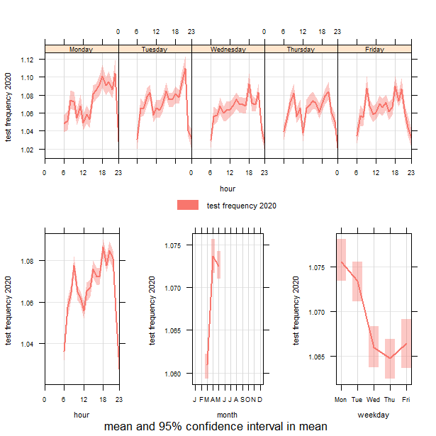

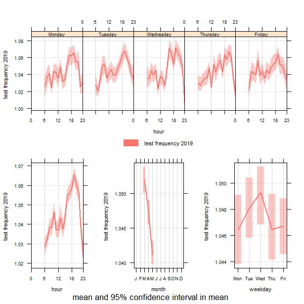

## Experienced Broadband Speeds

- An overall trend of increased testing from March to April and then a slight reduction from April to May in 2020, compared to less testing as Spring progresses in 2019
- $2019$ evening peak of testing, leisure activities, download speeds
- $2020$ **new morning peak** $\Rightarrow$ flatter hourly temporal profile

# Analysis

## Aggregation

- Relatively scarce data to analyse as stream
- Composite week time series
- Mon-Friday, hourly $6:00$ – $24:00$, excl. bank holidays
- $18$ hourly data points $x$ $5$ weekdays ($90$) for each local authority ($382$)
- Focus on upload speeds

## Time series clustering

- *Aim*: create clusters of local authorities with similar temporal signatures of internet speed
- Shape-based approach
- Match two separate time-series objects based on the similarity of their shapes
- Distances between the shapes
- Simplicity:
  - *k*-means
  - medoids, time-series objects with a minimal distance to all other cluster objects

**Upload speed cluster characteristics**

| Cluster | N. of LADs | LAD population | mean speed | SD speed | mean AM speed | mean PM speed |
| --- | --- | --- | --- | --- | --- | --- |
| 1 | 9 | 903200 | 9564 | 6314 | 8798 | 10457 |
| 2 | 2 | 162000 | 12085 | 6537 | 11882 | 10866 |
| 3 | 12 | 1785800 | 11047 | 6079 | 10029 | 11634 |
| 4 | 1 | 91100 | 9689 | 6122 | 7816 | 9689 |
| 5 | 3 | 280000 | 10802 | 6116 | 11010 | 10084 |
| 6 | 229 | 40552800 | 8761 | 5847 | 8555 | 8955 |
| 7 | 5 | 682500 | 10326 | 6102 | 10045 | 11149 |
| 8 | 6 | 510000 | 9769 | 6352 | 8989 | 10836 |
| 9 | 115 | 21467800 | 10328 | 5915 | 10283 | 10333 |
| Note: All speed measures are upload speeds |  |  |  |  |  |  |

## Time series clustering

- Cluster 1: Medium sized mostly rural cluster; slow mean upload speeds; high workday temporal variation.
- Cluster 2: Small rural cluster; highest mean upload speeds; slowdown more in evening.
- Cluster 3: Medium sized mixed cluster; fast mean upload speeds; medium temporal variation.
- Cluster 4: Rural reference LAD; medium mean upload speeds; high temporal variation.
- Cluster 5: Small suburban cluster; fast mean upload speeds; slowdown more in evening.
- **Cluster 6: Large mixed cluster; slowest aggregate mean upload speeds; low workday temporal variation.**
- Cluster 7: Small suburban cluster; fast mean upload speeds; medium temporal variation.
- Cluster 8: Small mainly suburban cluster; slow mean upload speeds; high workday temporal variation.
- **Cluster 9: Large, more urban cluster; fast mean upload speeds; lowest workday temporal variation.**

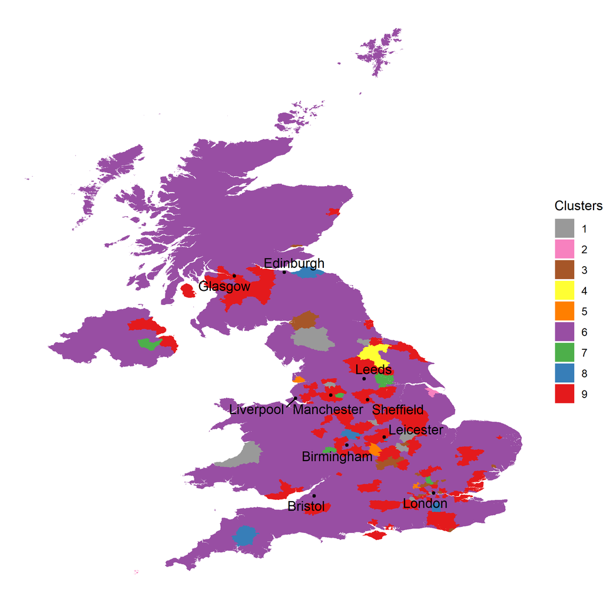

## Post-clustering regression analysis

- Explain the characteristics of clusters
- How the 1st level of the digital divide intersects with the 2nd and 3rd?
- Multinomial logit regression: cluster membership against:
  - population
  - pop. and job density
  - distance to nearest met. area and to London, South of the UK dummy
  - % of managerial, tech, skilled trade, professional, administrative, leisure, machine operation jobs
  - earnings, n. business est. per hab.
  - % furloughed pop., 2020
  - AM broadband tests per hab.
  - % of Virgin Media connections

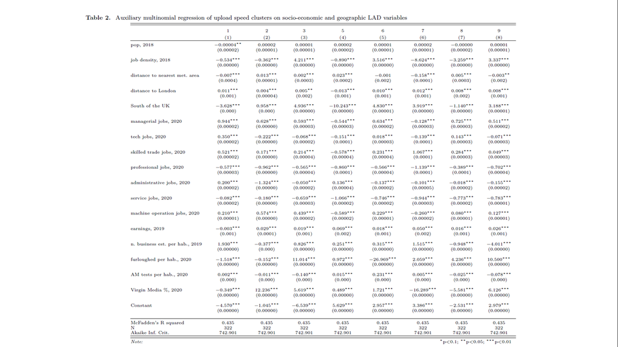

## Clusters 6 and 9

- Although speeds were slow and not as reliable during the morning peak as in cluster 9, the skills that enabled telecommuting also enabled **greater returns** from doing so ($\Downarrow$ furloughed)
- LADs in cluster 9 were able to benefit both from reliable internet connections and populations able to work from home to capitalise on their digital infrastructure
- But **lower returns** in the pandemic $\Rightarrow$ greater numbers furloughed

## Being on the right side of digital divides

- Clusters 3, 7 and 9 are on the right side of the 1st layer of digital divide
- Internet resilience supports, but also frustrates urban economies in different geographies:
  - $\Uparrow$ morning peak tests per capita run in cluster 6
- Being on the right side of the 2nd level digital divide had a **greater impact on economic resilience** (3rd level digital divide), than having quality internet connectivity
  - $\Rightarrow$ cluster 1 and 6

# Conclusions

- Seven of our nine clusters had slower upload speeds in the morning than in the evening
- Evidence of widespread telecommuting and other daytime internet use (e.g. education) which changed the temporal profile of internet activity throughout the UK
- Upload speeds have not previously been seen as integral to universal service, considering there has never before been such extreme demand for telecommuting and operations such as video calls
- Τelecommuting from the viewpoint of the complex web of digital divides
- Quality of internet infrastructure
- Places may depend upon good internet reliability and connectivity to achieve economic resilience in a period like the current pandemic
- Νot every place hosts individuals with the necessary *skills* and in *occupations* to effectively use the internet to telecommute

# References

Brynjolfsson, Erik, John J Horton, Adam Ozimek, Daniel Rock, Garima Sharma, and Hong-Yi TuYe. 2020. “COVID-19 and Remote Work: An Early Look at US Data.” National Bureau of Economic Research.

Dingel, Jonathan I, and Brent Neiman. 2020. “How Many Jobs Can Be Done at Home?” Working Paper 26948. Working Paper Series. National Bureau of Economic Research. https://doi.org/10.3386/w26948.

Eurofound. 2020. “Living, Working and COVID-19.” *COVID-19 Series*. https://www.eurofound.europa.eu/publications/report/2020/living-working-and-covid-19.

Nardotto, Mattia, Tommaso Valletti, and Frank Verboven. 2015. “Unbundling the Incumbent: Evidence from UK Broadband.” *Journal of the European Economic Association* 13 (2): 330–62.

ONS. 2020a. “Coronavirus and Homeworking in the UK: April 2020.” 2020. https://www.ons.gov.uk/employmentandlabourmarket/peopleinwork/employmentandemployeetypes/bulletins/coronavirusandhomeworkingintheuk/april2020.

———. 2020b. “Coronavirus and Homeworking in the UK Labour Market: 2019.” 2020. https://www.ons.gov.uk/employmentandlabourmarket/peopleinwork/employmentandemployeetypes/articles/coronavirusandhomeworkingintheuklabourmarket/2019.

Riddlesden, Dean, and Alex D Singleton. 2014. “Broadband Speed Equity: A New Digital Divide?” *Applied Geography* 52: 25–33.